# Rmarkdown Tutorial

Court Campany

February 1, 2018

# Introduction to Rmarkdown

## Here are the basics for typing in a markdown file

You can do all normal typing operations in this file. See the use of hashtags for headers and subheaders. Once you get the hang of it, you wont have to point and click you mouse everyting you want to make a <sub>subscript</sub> or a <sup>superscipt</sup>. **How cool is that!**. Since I am a scientist, I might also want to let you know that my spirit animal is a *Enhydra lutris*.

There are a few ways to make a line break. You will need to tell knitr when these need to occur. The first is to to end a sentence with two or more spaces plus return.

Another way, which is more visual, is to use return + backslash. I like this way because I can see it

To be honest that is really all you need to know to get started. **Pretty dang easy**!. If you really become interested we can learn how to cite articles with an automatically generated bibliography.

## Code Chunks

Lets breakdown code chucks. The chunk starts and ends with three accent characters, which are found left of the number keys. You can use this to make your own chunk…or…just click insert tab above and choose ‘R’. You can do everything inside the code chuck as normal. However, I usually have a seperate Rscript were I work out all the kinks of making the pretty figure. I dont like having to render the markdown over and over to look at a figure. This is more of the final product.

# Results

## The relationship between petal width and length

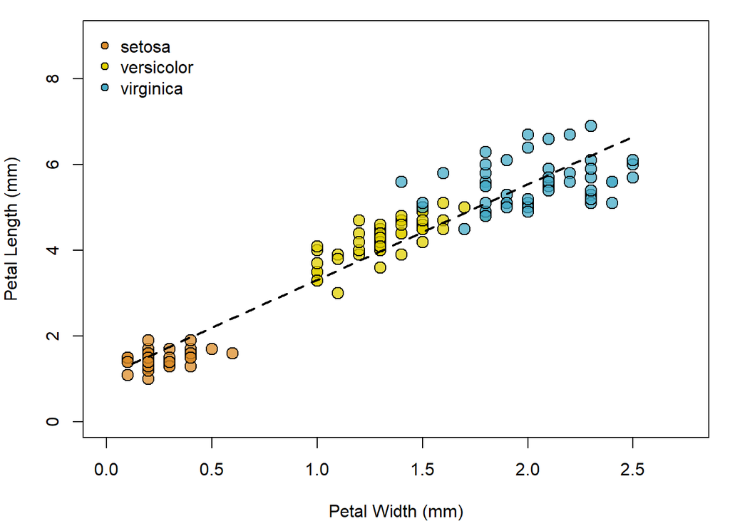